# **Portafolios de Inversión**

## **Profesor: Sean Nicolás González Vásquez**

## Tarea 2

### **Fecha:** 7 de septiembre de 2026

### **Integrantes:**

Diego Dueñas Martin

Gibrán Leonardo Chávez González

**Aviso**  
Toda la información compilada en relación a los tickers es del 2020-01-01 al 2026-08-31.

Para la elaboración de este portafolio, se eligieron 4 activos en relación a la correlación de los mismos, los activos tienen los siguientes tickers:

`ED`, `NUS`, `MDGL`, `TRMD`

Las cuatro empresas pertenecen a actividades económicas muy diferentes: servicios públicos, productos de cuidado personal, transporte marítimo y biotecnología. Esta variedad busca que sus acciones no reaccionen de la misma manera ante los mismos acontecimientos. Sin embargo, pertenecer a sectores distintos no garantiza por sí mismo una baja correlación ni elimina el riesgo.

**`Consolidated Edison (ED)`**

Es una sociedad controladora de servicios públicos regulados. CECONY suministra electricidad y gas en Nueva York y Westchester, y vapor en partes de Manhattan. Orange & Rockland opera en zonas de Nueva York y Nueva Jersey; Con Edison Transmission participa en proyectos de transmisión. Obtiene la mayor parte de sus ingresos mediante servicios regulados de electricidad, gas y vapor, esto significa que no puede fijar libremente todas sus tarifas, debe solicitar autorización para recuperar sus costos y obtener un rendimiento sobre sus inversiones. Su negocio puede ser relativamente estable porque ofrece servicios esenciales, pero necesita invertir grandes cantidades en mantenimiento y ampliación de sus redes. Por ello, las decisiones regulatorias, el costo de la deuda, las tormentas y las fallas de infraestructura pueden afectar sus resultados. Las tarifas reguladas buscan recuperar costos y permitir un rendimiento sobre el capital invertido. Mantener y ampliar las redes requiere inversiones continuas. La empresa prevé financiarlas mediante recursos operativos, deuda y capital accionario.

**`Nu Skin Enterprises (NUS)`**

Nu Skin nació en 1984. Su expansión internacional y posterior incorporación de Pharmanex ampliaron un negocio inicialmente vinculado al cuidado de la piel hacia nutrición y bienestar. La compañía cotiza en Nueva York bajo NUS desde 1996.

| Línea o unidad | Actividad principal |
| --- | --- |
| Nu Skin | Belleza y cuidado personal. |
| Pharmanex | Bienestar y suplementos. |
| ageLOC | Productos y dispositivos de belleza y cuidado personal. |
| Rhyz | Negocios de manufactura, consumo y tecnología complementarios. |

La venta de productos se apoya en afiliados que recomiendan y distribuyen sus artículos. Las compensaciones pueden vincularse a ventas propias y de la red, según el plan comercial; China continental opera con un esquema distinto por sus restricciones locales. Rhyz también vende a clientes externos.

Nu Skin obtiene ingresos vendiendo productos de belleza, cuidado personal y bienestar. Una parte importante de su modelo depende de afiliados y vendedores que recomiendan los productos y desarrollan redes comerciales. Por ello, no basta con tener productos atractivos: la empresa también necesita conservar una fuerza de ventas activa y cumplir distintas reglas en cada país. Su presencia internacional le permite llegar a más consumidores, pero también la expone a cambios en las monedas, las preferencias de compra y la regulación.

**`TORM plc (TRMD)`**

TORM fue fundada en 1889 y se especializa en buques tanque que transportan productos petrolíferos refinados y químicos. Cotiza en Nueva York y Copenhague. Su plataforma One TORM integra la actividad comercial y la operación de su flota, cobra fletes por transportar cargas, el ingreso depende de las tarifas, los días de operación y el uso de la flota; los costos incluyen combustible, puertos, mantenimiento y operación.

Obtiene ingresos cobrando por transportar productos petrolíferos refinados y químicos. Sus resultados dependen de las tarifas de transporte, los días que sus buques están operando y los costos de cada viaje. El TCE permite aproximar cuánto genera la flota después de descontar determinados gastos del viaje. Cuando las rutas se alargan o hay pocos buques disponibles, las tarifas pueden aumentar; cuando existe demasiada capacidad o baja demanda, pueden disminuir.

**`Madrigal Pharmaceuticals (MDGL)`**

Madrigal es una biofarmacéutica enfocada en MASH, enfermedad hepática metabólica antes denominada NASH. Su producto principal es Rezdiffra (resmetirom). La compañía vende mediante distribuidores y farmacias especializadas y utiliza fabricantes externos. Su desarrollo comercial depende de la prescripción, el acceso de pacientes y el reembolso. La diferenciación del medicamento y la protección de propiedad intelectual son relevantes para competir.

Aquí cabe resaltar un dato importante para el análisis posterior, un evento ocurrido el 19 de diciembre de 2022.

El comunicado *Madrigal announces positive topline results from the pivotal phase 3 MAESTRO-NASH clinical trial of resmetirom for the treatment of NASH and liver fibrosis* informó que resmetirom alcanzó ambos objetivos principales del ensayo a las 52 semanas. La compañía indicó su intención de solicitar aprobación acelerada; el anuncio no constituía todavía una aprobación.

La población principal de eficacia modificada incluyó 955 pacientes. Los porcentajes comunicados fueron los siguientes:

| Resultado a 52 semanas | 80 mg n = 316 | 100 mg n = 321 | Placebo n = 318 |
| --- | --- | --- | --- |
| Resolución de NASH con reducción de al menos 2 puntos de NAS, sin empeorar fibrosis | 26% | 30% | 10% |
| Mejora de al menos una etapa de fibrosis, sin empeorar NAS | 24% | 26% | 14% |

¿Por qué esto es relevante? Bueno, debido a esto, el precio del activo se disparó:

| Evidencia de la serie de MDGL | Resultado |
| --- | --- |
| Cierre ajustado del 16-dic-2022 | USD 63.80 |
| Cierre ajustado del 19-dic-2022 | USD 234.83 |
| Rendimiento simple entre ambos cierres | +268.07% |

[figure not shown]

*Fuente: Yahoo Finance.*

Ahora, la elaboración del portafolio.

Importación de librerías

```python
import yfinance as yf
import pandas as pd
import matplotlib.pyplot as plt
import numpy as np
import seaborn as sns
```

Definimos los tickers de los activos con los que vamos a construir nuestro portafolio

```python
ticker = ['ED', 'NUS', 'MDGL', 'TRMD']
```

Descargamos los precios de cierre en las fechas asignadas

```python
prices = yf.download(ticker,  start='2020-01-01', end='2026-08-31')['Close']
prices
```

```
[*********************100%***********************]  4 of 4 completed
```

| Ticker Date | ED | MDGL | NUS | TRMD |
| --- | --- | --- | --- | --- |
| 2020-01-02 | 69.760574 | 90.680000 | 31.672356 | 4.912580 |
| 2020-01-03 | 69.580017 | 86.980003 | 31.633183 | 4.912580 |
| 2020-01-06 | 69.352348 | 87.029999 | 31.390326 | 4.678647 |
| 2020-01-07 | 68.826355 | 85.660004 | 31.170996 | 4.678647 |
| 2020-01-08 | 68.276802 | 86.650002 | 31.641016 | 4.996796 |
| ... | ... | ... | ... | ... |
| 2026-08-24 | 107.709999 | 511.970001 | 4.710250 | 31.639999 |
| 2026-08-25 | 107.089996 | 512.159973 | 4.789248 | 31.469999 |
| 2026-08-26 | 108.050003 | 538.880005 | 4.779374 | 30.080000 |
| 2026-08-27 | 106.690002 | 543.690002 | 4.730000 | 31.799999 |
| 2026-08-28 | 107.489998 | 533.760010 | 4.850000 | 32.619999 |

1673 rows × 4 columns

Definimos los pesos de cada activo, en este caso será un portafolio equiponderado

```python
weights = np.ones(4) / 4
weights
```

```
array([0.25, 0.25, 0.25, 0.25])
```

Calculamos los rendimientos diarios de cada activo

```python
daily_rets= prices.pct_change().dropna()
daily_rets
```

| Ticker Date | ED | MDGL | NUS | TRMD |
| --- | --- | --- | --- | --- |
| 2020-01-03 | -0.002588 | -0.040803 | -0.001237 | 0.000000 |
| 2020-01-06 | -0.003272 | 0.000575 | -0.007677 | -0.047619 |
| 2020-01-07 | -0.007584 | -0.015742 | -0.006987 | 0.000000 |
| 2020-01-08 | -0.007985 | 0.011557 | 0.015079 | 0.068000 |
| 2020-01-09 | -0.001035 | 0.044432 | 0.010646 | 0.000000 |
| ... | ... | ... | ... | ... |
| 2026-08-24 | 0.012788 | -0.009231 | 0.006329 | -0.005031 |
| 2026-08-25 | -0.005756 | 0.000371 | 0.016772 | -0.005373 |
| 2026-08-26 | 0.008964 | 0.052171 | -0.002062 | -0.044169 |
| 2026-08-27 | -0.012587 | 0.008926 | -0.010331 | 0.057181 |
| 2026-08-28 | 0.007498 | -0.018264 | 0.025370 | 0.025786 |

1672 rows × 4 columns

### Rendimiento diario del portafolio

```python
daily_means = daily_rets.mean()
daily_means
```

```
Ticker
ED      0.000367
MDGL    0.002499
NUS    -0.000552
TRMD    0.001769
dtype: float64
```

```python
daily_ret_port = weights @ daily_means
daily_ret_port
```

```
np.float64(0.001020764544666786)
```

### Rendimiento anual del portafolio

```python
annual_ret_port = daily_ret_port * 252
annual_ret_port
```

```
np.float64(0.25723266525603006)
```

### Varianza diaria del portafolio

Primero requerimos la matriz de covarianzas

```python
cov_matrix = daily_rets.cov()
cov_matrix
```

| Ticker | ED | MDGL | NUS | TRMD |
| --- | --- | --- | --- | --- |
| ED | 2.180787e-04 | 0.000018 | -1.278033e-05 | 3.839245e-07 |
| MDGL | 1.809859e-05 | 0.005537 | 1.215067e-04 | -2.394131e-06 |
| NUS | -1.278033e-05 | 0.000122 | 1.192457e-03 | -1.364005e-07 |
| TRMD | 3.839245e-07 | -0.000002 | -1.364005e-07 | 1.340560e-03 |

```python
daily_risk_port = weights.T @ cov_matrix @ weights
daily_risk_port
```

```
np.float64(0.0005335857862544826)
```

### Varianza anual del portafolio

```python
annual_risk_port = daily_risk_port * 252
annual_risk_port
```

```
np.float64(0.13446361813612961)
```

### Volatilidad diaria del portafolio

```python
daily_vol_port = np.sqrt(daily_risk_port)
daily_vol_port
```

```
np.float64(0.023099475887008402)
```

### Volatilidad anual del portafolio

```python
annual_vol_port = daily_vol_port * np.sqrt(252)
annual_vol_port
```

```
np.float64(0.36669281167774426)
```

### Matriz de correlación

```python
correlation_matrix = daily_rets.corr()
correlation_matrix
```

| Ticker | ED | MDGL | NUS | TRMD |
| --- | --- | --- | --- | --- |
| ED | 1.000000 | 0.016470 | -0.025062 | 0.000710 |
| MDGL | 0.016470 | 1.000000 | 0.047287 | -0.000879 |
| NUS | -0.025062 | 0.047287 | 1.000000 | -0.000108 |
| TRMD | 0.000710 | -0.000879 | -0.000108 | 1.000000 |

#### Rendimiento y Volatilidad anual de cada activo por separado y del portafolio

Esto nos servirá para poder ampliar nuestras conclusiones más adelante.

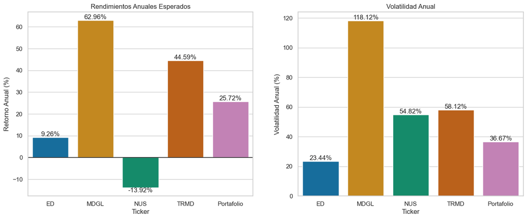

```python
# Calculamos la desviación estándar anual (Volatilidad)
annual_vol = daily_rets.std() * np.sqrt(252)

# Preparamos los datos para graficar
comparation_df = pd.DataFrame({
    'Retorno Anual (%)': daily_means * 252 * 100,
    'Volatilidad Anual (%)': annual_vol * 100
})

# Agregar las métricas del portafolio al DataFrame
comparation_df.loc['Portafolio'] = [annual_ret_port * 100, annual_vol_port * 100]

# Configuración de estilo
sns.set_theme(style='whitegrid')
fig, axes = plt.subplots(1, 2, figsize=(16, 6))

# Gráfica de Rendimientos
sns.barplot(
    x=comparation_df.index,
    y='Retorno Anual (%)',
    data=comparation_df,
    ax=axes[0],
    palette='colorblind',
    hue=comparation_df.index,
    legend=False
)
axes[0].set_title('Rendimientos Anuales Esperados')
axes[0].axhline(0, color='black', linewidth=1)
for container in axes[0].containers:
    axes[0].bar_label(
        container,
        fmt='%.2f%%',
        label_type='edge'
    )

# Gráfica de Volatilidad
sns.barplot(
    x=comparation_df.index,
    y='Volatilidad Anual (%)',
    data=comparation_df,
    ax=axes[1],
    palette='colorblind',
    hue=comparation_df.index,
    legend=False
)
axes[1].set_title('Volatilidad Anual')
for container in axes[1].containers:
    axes[1].bar_label(
        container,
        fmt='%.2f%%',
        label_type='edge'
    )

plt.show()
```

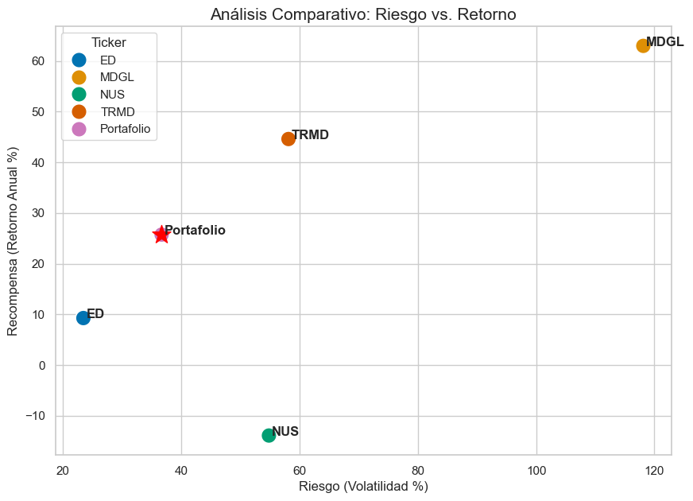

```python
# Gráfica de Riesgo vs Retorno
plt.figure(figsize=(10, 7))
sns.scatterplot(
    data=comparation_df,
    x='Volatilidad Anual (%)',
    y='Retorno Anual (%)',
    s=200,
    hue=comparation_df.index,
    palette='colorblind'
)

# Mostrar portafolio con un marcador estrellado y más grande
plt.scatter(
    comparation_df['Volatilidad Anual (%)'].loc['Portafolio'],
    comparation_df['Retorno Anual (%)'].loc['Portafolio'],
    color='red',
    s=300,
    marker='*',
    label='Portafolio'
)

# Añadir etiquetas a los puntos
for i in range(comparation_df.shape[0]):
    plt.text(
        comparation_df['Volatilidad Anual (%)'].iloc[i]+0.5,
        comparation_df['Retorno Anual (%)'].iloc[i],
        comparation_df.index[i],
        fontsize=12,
        weight='bold'
    )

plt.title('Análisis Comparativo: Riesgo vs. Retorno', fontsize=15)
plt.xlabel('Riesgo (Volatilidad %)')
plt.ylabel('Recompensa (Retorno Anual %)')
plt.grid(True)
plt.show()
```

### Conclusiones sobre la matriz de correlación y el riesgo no sistemático de cada activo

#### Matriz de Correlación

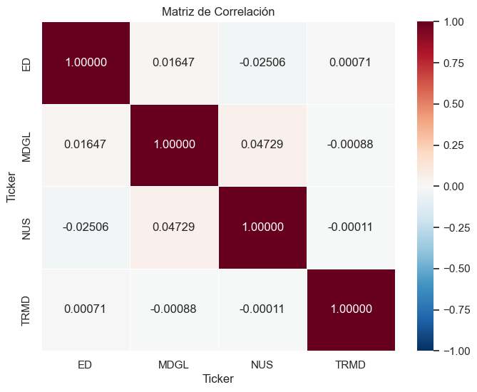

```python
# Graficar correlación
plt.figure(figsize=(8, 6))
sns.heatmap(
    correlation_matrix,
    annot=True,
    cmap='RdBu_r',
    vmin=-1,
    vmax=1,
    center=0,
    fmt='.5f',
    linewidths=0.5
)
plt.title('Matriz de Correlación')
plt.show()
```

Como se ve en la matriz de correlación, todas las correlaciones están bastante cercanas a cero.

El par con la mayor correlación positiva es MDGL-NUS, con aproximadamente 0.0473. Aunque es el valor más alto de la matriz, continúa siendo muy cercano a cero, por lo que no puede afirmarse que ambas acciones hayan tenido una tendencia constante a subir o bajar juntas. Por otro lado, ED-NUS presenta la correlación negativa de mayor magnitud, con aproximadamente -0.0251. Este resultado tampoco es suficientemente grande como para considerar que ED funcione como una protección frente a las caídas de NUS.

Las correlaciones entre TRMD y las demás acciones son prácticamente nulas. Esto sugiere que los cambios diarios en el precio de TORM estuvieron relacionados principalmente con factores diferentes de los que influyeron sobre Consolidated Edison, Nu Skin y Madrigal. Esta diferencia puede entenderse al observar sus actividades. TORM depende de las tarifas de transporte marítimo y de la operación de su flota, ED de servicios públicos regulados, NUS de las ventas de productos de belleza y bienestar y Madrigal de acontecimientos clínicos, regulatorios y comerciales relacionados con sus medicamentos.

La variedad de negocios ayuda a explicar la baja correlación, pero no la demuestra por sí sola. Dos empresas pueden pertenecer a sectores diferentes y, aun así, reaccionar de manera parecida ante una recesión, una crisis financiera, un aumento de tasas de interés o una caída general del mercado. Por ello, la matriz debe interpretarse como evidencia histórica de una baja relación lineal y no como una "garantía" de que las acciones continuarán comportándose de esa manera.

También es importante señalar que una correlación cercana a cero no significa que los activos sean independientes. La correlación resume el comportamiento promedio durante todo el periodo y puede ocultar días en los que las acciones se movieron en la misma dirección. Por ejemplo, el 16 de marzo de 2020 las cuatro posiciones registraron rendimientos negativos y el portafolio perdió aproximadamente 11.94% en una sola sesión. Esto demuestra que una baja correlación no impide que aparezcan pérdidas simultáneas durante periodos de tensión.

Por tanto, sí que existe un beneficio potencial de diversificación, debido a que los cuatro activos no se movieron de forma perfectamente sincronizada. Sin embargo, la matriz no permite concluir que el portafolio sea de bajo riesgo, que las acciones nunca caerán juntas o que las correlaciones se mantendrán constantes en el futuro.

#### Riesgo no sistemático de cada activo

El riesgo no sistemático es el relacionado con situaciones particulares de una empresa. Algunos ejemplos son una falla operativa, un producto que no logra venderse, un accidente, una decisión regulatoria específica o un resultado clínico inesperado. A diferencia de los acontecimientos generales del mercado, estos riesgos pueden reducirse al combinar empresas que dependan de actividades distintas, que es justo lo que se busca al diversificar un postafolio.

La correlación ayuda a observar si los efectos de esos riesgos particulares tienden a presentarse al mismo tiempo. Cuando las correlaciones son bajas, un problema en una empresa no necesariamente produce el mismo movimiento en las demás. Por ejemplo, un resultado clínico desfavorable para Madrigal no debería afectar directamente las tarifas reguladas de Consolidated Edison ni el número de viajes realizados por los buques de TORM. En ese sentido, la baja correlación puede disminuir la dependencia del portafolio respecto de un solo acontecimiento empresarial.

No obstante, la matriz de correlación no separa directamente el riesgo sistemático del no sistemático. La volatilidad calculada para cada acción incluye ambos, para medir estadísticamente el riesgo específico sería necesario comparar cada acción con un índice de mercado u otros factores y observar qué parte de sus movimientos no queda explicada por ellos.

`Consolidated Edison (ED) | Servicios públicos`

El riesgo particular de Consolidated Edison se relaciona principalmente con la regulación de sus tarifas, la recuperación de sus inversiones y la operación de sus redes. La empresa necesita invertir constantemente en infraestructura eléctrica y de gas, por lo que si los reguladores no autorizan tarifas suficientes para cubrir sus costos y ofrecer un rendimiento adecuado, sus resultados podrían verse afectados, ED presenta una volatilidad anualizada de aproximadamente 23.44%, siendo la menor de los cuatro activos. Esto es consistente y razonable con un negocio que ofrece servicios esenciales y obtiene una parte importante de sus ingresos mediante tarifas reguladas. Sin embargo, su menor volatilidad no significa ni implica que esté libre de riesgo.

Otros riesgos propios incluyen fallas en la red, interrupciones del servicio, accidentes, daños provocados por tormentas y problemas de seguridad informática, ya que estos acontecimientos pueden generar costos de reparación, compensaciones o sanciones que no necesariamente afectarían de la misma forma a las otras empresas del portafolio. Su aportación aproximada de 2.62% a la varianza del portafolio es considerablemente menor que su peso de 25%. Esto se explica por su menor volatilidad y por su reducida relación con las otras acciones. En consecuencia, ED funciona como el componente relativamente más estable de la combinación, aunque no puede considerarse una inversión segura ni una protección garantizada durante las caídas del mercado.

`Nu Skin Enterprises (NUS) | Consumo básico / cuidado personal`

Los principales riesgos particulares de Nu Skin se relacionan con la aceptación de sus productos, la permanencia de sus clientes y afiliados, los lanzamientos comerciales y el cumplimiento de las reglas aplicables a la venta directa, por lo que una pérdida de confianza en la marca, mala reputación una reducción en el número de vendedores o el fracaso de un nuevo producto puede afectar sus ingresos. La presencia internacional de la empresa proporciona acceso a distintos mercados, pero también crea exposición a cambios en las reglas comerciales, especialmente en países donde la venta directa está más restringida y moderada. Asimismo, las variaciones en monedas extranjeras y en las preferencias de los consumidores pueden afectar sus resultados. Una parte de esos riesgos es propia de Nu Skin, mientras que otra está relacionada con condiciones económicas y comerciales más generales.

NUS registró una volatilidad anualizada cercana a 54.82% y un rendimiento esperado negativo de aproximadamente 13.92%, esto indica que durante el periodo fue una acción con fluctuaciones considerables y además, un desempeño desfavorable. Su peso de 25% provocó que restara cerca de 3.48 puntos porcentuales a la rendimiento esperado anualizado del portafolio. A pesar de ello, NUS aportó diversificación porque sus movimientos mostraron poca relación con los demás activos, su participación aproximada de 15.24% en la varianza indica que contribuyó al riesgo conjunto, pero en una proporción menor que su peso de capital. Este caso demuestra que un activo puede ayudar a reducir la concentración de riesgo y, al mismo tiempo, perjudicar el rendimiento.

`TORM (TRMD) | Energía / transporte de petróleo y gas`

Los riesgos particulares de TORM se relacionan con la operación de sus buques, entre ellos se encuentran accidentes, daños, fallas de mantenimiento, periodos durante los cuales un barco no puede operar y pérdida de autorizaciones de clientes importantes, también existe el riesgo de que la empresa compre o venda buques en momentos poco favorables. Sus ingresos dependen de las tarifas cobradas por transportar productos petrolíferos, la cantidad de días en que sus barcos están trabajando y los costos de combustible, mantenimiento y operación. Parte de estos riesgos pertenece a toda la industria marítima, especialmente los cambios en las tarifas, las rutas internacionales y la oferta de buques. Por eso no todo el riesgo de TORM puede considerarse exclusivamente de la empresa.

TRMD tuvo una volatilidad anualizada de aproximadamente 58.12%, lo que demuestra que su baja correlación no la convierte en una acción estable, al mismo tiempo, su rendimiento de 44.59% fue una de las principales aportaciones positivas al rendimiento del portafolio. Debido a su peso de 25%, contribuyó con aproximadamente 11.15 puntos porcentuales a la media anualizada conjunta.

`Madrigal Pharmaceuticals (MDGL) | Salud / biotecnología`

Madrigal presenta el riesgo particular más evidente de los cuatro activos porque una parte importante de su valor depende de Rezdiffra. Los resultados clínicos, las decisiones regulatorias, la seguridad del medicamento, la aceptación de los médicos, la cobertura de las aseguradoras y la capacidad de llegar a los pacientes pueden producir cambios importantes en sus expectativas de ingresos. El anuncio del 19 de diciembre de 2022 ayuda a observar este tipo de riesgo, Madrigal comunicó resultados positivos de su ensayo clínico y la acción registró un rendimiento aproximado de 268.07% respecto del cierre anterior. Esta coincidencia entre ambos hechos no permite darle todo el crédito del movimiento solo al anuncio, pero sí muestra cómo una nueva información relacionada con un medicamento puede modificar rápidamente la valoración de una empresa biofarmacéutica.

MDGL presenta una volatilidad anualizada cercana a 118.12%, altísima, la mayor del portafolio, su rendimiento de 62.96% también es el más alto, pero se encuentra fuertemente influido por el movimiento extraordinario y extremo de 2022. Por lo tanto, no debe interpretarse como una tasa de crecimiento que la empresa pueda replicar cada año. Aunque Madrigal representa únicamente 25% del capital, aporta aproximadamente 66.46% de la varianza conjunta, esto significa que es la principal fuente de riesgo del portafolio. Su baja correlación con las otras acciones ayuda a evitar que todo el portafolio replique sus movimientos, pero no elimina el impacto que podría tener una caída importante.

### Conclusiones sobre las métricas de rendimiento y riesgo del portafolio, además de la diversificación del mismo

#### Métricas del portafolio

```python
columns = ['Rendimiento diario (%)', 'Rendimiento anual (%)',  'Varianza diaria', 'Varianza anual', 'Volatilidad diaria (%)', 'Volatilidad anual (%)']
values = [daily_ret_port * 100, annual_ret_port * 100, daily_risk_port, annual_risk_port, daily_vol_port * 100, annual_vol_port * 100]

metrics_portafolio_df = pd.DataFrame([values], columns=columns, index=['Portafolio'])

metrics_portafolio_df.style \
    .hide(axis='index') \
    .set_caption('Rendimiento y Volatilidad del Portafolio')
```

Rendimiento y Volatilidad del Portafolio

| Rendimiento diario (%) | Rendimiento anual (%) | Varianza diaria | Varianza anual | Volatilidad diaria (%) | Volatilidad anual (%) |
| --- | --- | --- | --- | --- | --- |
| 0.102076 | 25.723267 | 0.000534 | 0.134464 | 2.309948 | 36.669281 |

El portafolio se elaboró con pesos equitativos, es decir, 25% de peso para cada activo. Si analizamos el rendimiento y su volatilidad (anualizadas) por separado, vemos lo siguiente:

```python
# Métricas de activos individuales
metrics_individual_df = pd.DataFrame({
    'Rendimiento diario (%)': daily_means * 100,
    'Rendimiento anual (%)': daily_means * 252 * 100,
    'Varianza diaria': daily_rets.var(),
    'Varianza anual': daily_rets.var() * 252,
    'Volatilidad diaria (%)': daily_rets.std() * 100,
    'Volatilidad anual (%)': daily_rets.std() * np.sqrt(252) * 100
})

metrics_individual_df.style \
    .set_caption('Rendimiento y Volatilidad por Activo')
```

Rendimiento y Volatilidad por Activo

| Ticker | Rendimiento diario (%) | Rendimiento anual (%) | Varianza diaria | Varianza anual | Volatilidad diaria (%) | Volatilidad anual (%) |
| --- | --- | --- | --- | --- | --- | --- |
| ED | 0.036747 | 9.260172 | 0.000218 | 0.054956 | 1.476749 | 23.442661 |
| MDGL | 0.249854 | 62.963278 | 0.005537 | 1.395304 | 7.441048 | 118.122974 |
| NUS | -0.055226 | -13.916880 | 0.001192 | 0.300499 | 3.453197 | 54.817811 |
| TRMD | 0.176931 | 44.586496 | 0.001341 | 0.337821 | 3.661366 | 58.122391 |

El portafolio presenta un rendimiento promedio diario aproximado de 0.1021% y uno anual de 25.72%. Esta cifra resume el promedio de los rendimientos diarios, pero no significa que el portafolio haya ganado exactamente 25.72% cada año, lo que nos dice esta cifra es que el en el largo plazo los rendimientos tienden a ese valor.

El resultado fue impulsado principalmente por Madrigal y TORM. ED realizó una aportación positiva más moderada, mientras que Nu Skin redujo el promedio, esto demuestra que el rendimiento total no proviene de manera equilibrada de las cuatro acciones, aunque todas tengan el mismo peso.

La volatilidad diaria del portafolio es aproximadamente 2.31% y su volatilidad anualizada es 36.67%. Esta última cifra representa la intensidad de las fluctuaciones históricas. La volatilidad del portafolio es menor que la de NUS, TRMD y MDGL, pero mayor que la de ED. Por consiguiente, la diversificación logró reducir el riesgo en comparación con tres de las cuatro inversiones individuales, pero no produjo una combinación menos volátil que todos sus componentes.

Además, el rendimiento y la volatilidad deben analizarse juntos. Un rendimiento histórico elevado no es suficiente para calificar una inversión como favorable si fue necesario soportar oscilaciones muy grandes. En este caso, el rendimiento esperado del 25.72% estuvo acompañado de una volatilidad de 36.67% y de pérdidas importantes en ciertos momentos. Sin una referencia de mercado y una tasa libre de riesgo consistentes, no puede determinarse si la compensación por el riesgo fue superior a otras alternativas.

#### Diversificación del portafolio

Las métricas individuales muestran cuánto fluctuó y cuánto rindió cada activo por separado, la matriz de correlación muestra cómo se relacionaron esos movimientos, la volatilidad del portafolio reúne ambos elementos, es decir, depende tanto del riesgo individual de las acciones como de la forma en que se movieron entre sí. Por eso no basta con seleccionar acciones de baja correlación, ya que si una de ellas tiene una volatilidad extremadamente elevada, puede continuar dominando el riesgo del portafolio. Esto es precisamente lo que ocurre con MDGL, la correlación ayuda a reducir la transmisión de sus movimientos a las demás posiciones, pero su gran volatilidad hace que siga aportando aproximadamente dos terceras partes de la varianza.

El beneficio de la diversificación puede observarse mediante tres escenarios. Si los rendimientos de las cuatro acciones hubieran presentado una correlación positiva perfecta, la volatilidad equiponderada habría sido aproximadamente 63.63%. Con las correlaciones realmente observadas fue 36.67%. Si todas las correlaciones hubieran sido exactamente cero, habría resultado cercana a 36.13%. La diferencia entre 63.63% y 36.67% muestra que combinar activos que no se mueven juntos reduce considerablemente el riesgo frente a una situación de sincronización perfecta, sin embargo, la cercanía entre 36.67% y 36.13% señala que casi todo el riesgo restante proviene de las volatilidades individuales, especialmente de Madrigal (lo cual se entiende debido al caso extremo que presentó en el periodo de estudio).

Esto también permite distinguir entre repartir el capital y repartir el riesgo, cada activo recibe 25% del dinero, pero sus aportaciones a la varianza son muy diferentes. ED aporta aproximadamente 2.62%, NUS un 15.24%, TRMD un 15.68% y MDGL un 66.46%. En consecuencia, el portafolio está equiponderado en términos monetarios, pero no en términos de riesgo.

En conclusión, se podría decir que el portafolio presenta una diversificación favorable porque reúne empresas de cuatro actividades económicas diferentes y porque sus rendimientos históricos tuvieron correlaciones pequeñas. Esto disminuye la dependencia de una sola empresa y evita que todos los riesgos particulares se transmitan automáticamente a la combinación, sin embargo, la diversificación no está del todo "bien" hecha. Sólo existen cuatro emisores, cada uno representa una parte importante del capital y todas las posiciones pertenecen a renta variable, por lo que no hay diversificación entre diferentes clases de activos y permanece una fuerte concentración del riesgo en Madrigal.

#### Matriz de correlación sin el 2022-12-19

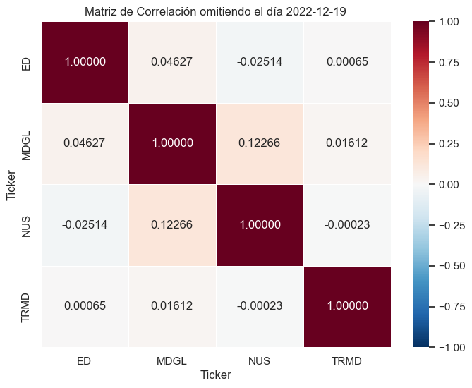

```python
correlation_matrix_no_outlier = daily_rets[daily_rets.index != '2022-12-19'].corr()
plt.figure(figsize=(8, 6))
sns.heatmap(
    correlation_matrix_no_outlier,
    annot=True,
    cmap='RdBu_r',
    vmin=-1,
    vmax=1,
    center=0,
    fmt='.5f',
    linewidths=0.5
)
plt.title('Matriz de Correlación omitiendo el día 2022-12-19')
plt.show()
```

## Referencias

Consolidated Edison, Inc. (s. f.). *Energy service companies: Frequently asked questions*. https://www.coned.com/en/save-money/shop-for-energy-service-companies/faq

Consolidated Edison, Inc. (2026). *Annual report 2025*. https://www.sec.gov/Archives/edgar/data/1047862/000104786226000064/annualreport25_finalv2.htm

Financial Industry Regulatory Authority. (s. f.). *Asset allocation and diversification*. https://www.finra.org/investors/investing/investing-basics/asset-allocation-diversification

Madrigal Pharmaceuticals, Inc. (2022, 19 de diciembre). *Madrigal announces positive topline results from the pivotal phase 3 MAESTRO-NASH clinical trial of resmetirom for the treatment of NASH and liver fibrosis* [Comunicado de prensa]. https://ir.madrigalpharma.com/node/14516/pdf

Madrigal Pharmaceuticals, Inc. (2026). *Annual report for the fiscal year ended December 31, 2025* [Form 10-K]. https://www.sec.gov/Archives/edgar/data/1157601/000162828026009514/mdgl-20251231.htm

MSCI. (2024, agosto). *Global Industry Classification Standard (GICS) methodology*. https://www.msci.com/indexes/documents/methodology/1_MSCI_Global_Industry_Classification_Standard_GICS_Methodology_20240801.pdf

Nu Skin Enterprises, Inc. (s. f.). *About Nu Skin: Helping you be your next-level best*. https://www.nuskin.com/gb/en/site/company/about-us

Nu Skin Enterprises, Inc. (2026). *Annual report for the fiscal year ended December 31, 2025* [Form 10-K]. https://ir.nuskin.com/node/24076/html

TORM plc. (s. f.). *Our company*. Recuperado el 3 de septiembre de 2026, de https://www.torm.com/about/our-company/default.aspx

TORM plc. (2026). *Annual report 2025*. https://s202.q4cdn.com/126069760/files/doc_financials/2025/ar/TORM-Annual-Report-2025.pdf

OpenAI. (2026). *ChatGPT* [Modelo de lenguaje de gran escala]. https://chatgpt.com/